# Topic models

## Topic models via *topicmodels*

Topic models are a useful tool for the statistical analysis of texts.

Illustrate the usage of topic models via the package "topicmodels".

Apply the methodology dataset "Last Words of Death Row Inmates" and "2016 U.S. Presidential Campaign Texts and Polls".

## Topic models

Topic modeling aims to discover and annotate large archives of documents with thematic information.

There are different models, in the *topicmodels* package there are:

- Latent Dirichlet Allocation
  - Variational Expectation Maximization and Gibbs sampling
- Correlated Topic Models
  - Variational Expectation Maximization

## Latent Dirichlet Allocation models (I)

LDA is a Bayesian Mixture Model which can be applied to the analysis of a corpus of documents.

LDA models each topic as a discrete distribution over a finite set of words, and each document as a finite distribution over the set of the \(K\) topics.

There is a generative model assumed, for which each document "chooses" a probability distribution over the set of all topics, and each time a word is drawn, first a topic is randomly chosen, then a word is drawn randomly from its associated distribution.

## Latent Dirichlet Allocation models (II)

Given \(\alpha\) and \(\beta\) parameters for the Dirichlet priors, LDA assumes therefore the following generative process:

- draw \(\theta_m\) and \(\phi_k\), respectively the topics and words distributions, from \(\mbox{Dir}(\alpha)\) and \(\mbox{Dir}(\beta)\)
- the topics \(z_{mn}\) are drawn from the categ. distributions \(\theta_m\)
- the words \(w_{mn}\) are drawn from the categ. distributions \(\phi_{z_{mn}}\)

LDA can be represented as a Probabilistic Graphical Model:

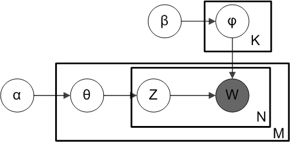

## Data cleaning and lemmatization

Often overlooked aspects; apart from the purely "programming-related" problems, some design decisions heavily affect the end results.

In this case, the stopwords set (set of words to be discarded during reading) and the stemming algorithm (that removes suffixes from words) can introduce noise or (in some sense) bias, unless carefully chosen.

## Dataset Last Words of Death Row Inmates (I)

This dataset includes information on criminals executed by Texas Department of Criminal Justice from 1982 to November 8th, 2017.

545 observations with 21 variables:

- Execution: The order of execution, numeric.
- LastName: Last name of the offender, character.
- FirstName: First name of the offender, character.
- TDCJNumber: TDCJ Number of the offender, numeric.
- Age: Age of the offender, numeric.
- Race: Race of the offender, categorical : Black, Hispanic, White, Other.
- CountyOfConviction: County of conviction, character.
- AgeWhenReceived: Age of offender when received, numeric.
- EducationLevel: Education level of offender, numeric.
- Native County: Native county of offender, categorical : 0 = Within Texas, 1= Outside Texas.
- PreviousCrime : Whether the offender committed any crime before, categorical: 0= No, 1= Yes.
- Codefendants: Number of co-defendants, numeric.
- NumberVictim: Number of victims, numeric.
- WhiteVictim, HispanicVictim, BlackVictim, VictimOtherRace. FemaleVictim, MaleVictim: Number of victims with specified demographic features, numeric.
- LastStatement: Last statement of offender, character.

## Dataset Last Words of Death Row Inmates (II)

|  | Execution | LastName | FirstName | Age | Race | CountyOfConviction | AgeWhenReceived | EducationLevel | NativeCounty | PreviousCrime | CoDefendants | NumberVictim | WhiteVictim | HispanicVictim | BlackVictim | VictimOtherRaces | FemaleVictim | MaleVictim |
| --- | --- | --- | --- | --- | --- | --- | --- | --- | --- | --- | --- | --- | --- | --- | --- | --- | --- | --- |
| 1 | 545 | Cardenas | Ruben | 47 | Hispanic | Hidalgo | 28 | 11 | 1 | 0 | 0 | 1 | 0 | 1 | 0 | 0 | 1 | 0 |
| 2 | 544 | Pruett | Robert | 38 | White | Bee | 22 | 8 | 0 | 1 | 0 | 1 | 1 | 0 | 0 | 0 | 0 | 1 |
| 3 | 543 | Preyor | Taichin | 46 | Black | Bexar | 34 | 10 | 0 | 0 | 0 | 1 | 1 | 0 | 0 | 0 | 0 | 1 |
| 4 | 542 | Bigby | James | 61 | White | Tarrant | 36 | 9 | 0 | 1 | 0 | 1 | 1 | 0 | 0 | 0 | 0 | 1 |
| 5 | 541 | Ruiz | Rolando | 44 | Hispanic | Bexar | 22 | 10 | 0 | 1 | 4 | 1 | 0 | 1 | 0 | 0 | 1 | 0 |
| 6 | 540 | Edwards | Terry | 43 | Black | Dallas | 30 | 12 | 0 | 1 | 1 | 1 |  |  |  |  | 1 | 0 |
| 7 | 538 | Fuller | Barney | 58 | White | Houston | 45 | 9 | 1 | 0 | 0 | 1 | 1 | 0 | 0 | 0 | 1 | 1 |
| 8 | 537 | Vasquez | Pablo | 38 | Hispanic | Hidalgo | 21 | 8 | 0 | 0 | 1 | 1 | 0 | 1 | 0 | 0 | 0 | 1 |
| 9 | 536 | Ward | Adam | 33 | White | Hunt | 24 |  | 0 | 0 | 0 | 1 | 1 | 0 | 0 | 0 | 0 | 1 |
| 10 | 535 | Wesbrook | Coy | 58 | White | Harris | 40 | 8 | 0 | 0 | 0 | 3 | 2 | 1 | 0 | 0 | 1 | 2 |

[output cut: 421 more lines]

## Last statements

|  | Last Statement |
| --- | --- |
| 1 | This is my statement: My final words. First, I want to thank my family for believing in me and being there with me till the end. I love you all very much! And I know that you love me too! Life does go… |
| 2 | I just want to let everyone in here to know I love you so much. I've hurt a lot of people and a lot of people have hurt me. I love y'all so much. Life don't end here it goes on forever. I've had to le… |
| 3 | First and foremost I'd like to say, "Justice has never advanced by taking a life" by Coretta Scott King. Lastly, to my wife and to my kids, I love y'all forever and always. That's it. |
| 4 | Yes, I do, Grace Kehler is that you? I have given Warden Jones a written statement that will explain a lot more. I hope this will bring you closure and answers to some questions. I hope this will brin… |
| 5 | Yes sir, I would first like to say to the Sanchez family how sorry I am. Words cannot begin to express how sorry I am and the hurt that I have caused you and your family. May this bring you peace and … |
| 6 | Yes, I made peace with God. I hope y'all make peace with this. |
| 7 | I don't have anything to say, you can proceed Warden Jones. |
| 8 | I just want to tell my family thank you, my mom and dad and sister and Sabrina. I love you Mercedes. I am sorry to David's family. This is only way that I can be forgiven. You got your justice right h… |
| 9 | I would like to thank everyone that has showed up on my behalf, Kathryn Cox, I love you dearly. Thank you Randy Cannon for showing up and being a lifelong friend. Thank you Dr. Steve Ball for trying t… |
| 10 | Yeah, first off, I want to say that I am sorry for the pain that I have caused you people. I am sorry that I cannot bring everybody back. I wish it could be different. I know it would be hard for you … |

[output cut: 421 more lines]

## Most used words in last statements

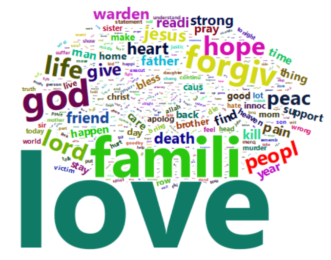

## LDA using VEM

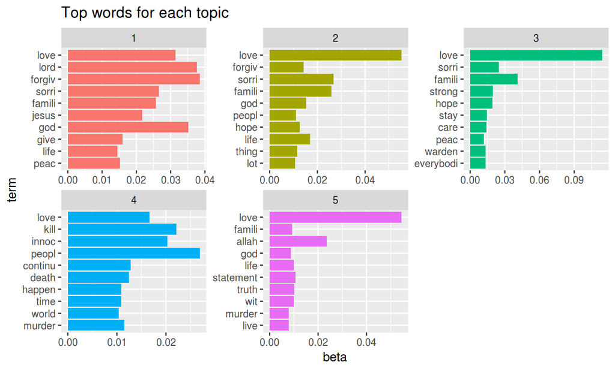

## Top relevant Words for each topic

\[relevance = \lambda*\log p(word|topic)+(1-\lambda)*\log\,\frac{p(word|topic)}{p(word)}\]

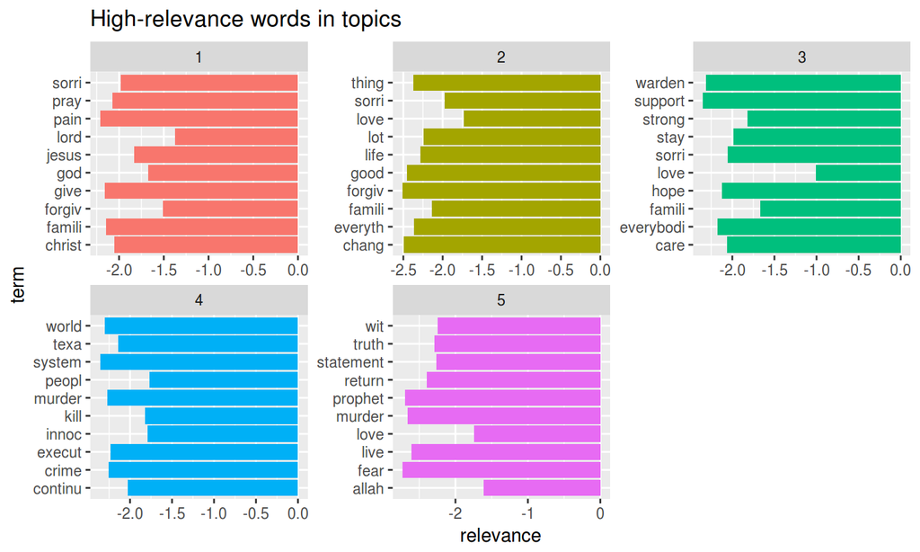

## Distribution of topics

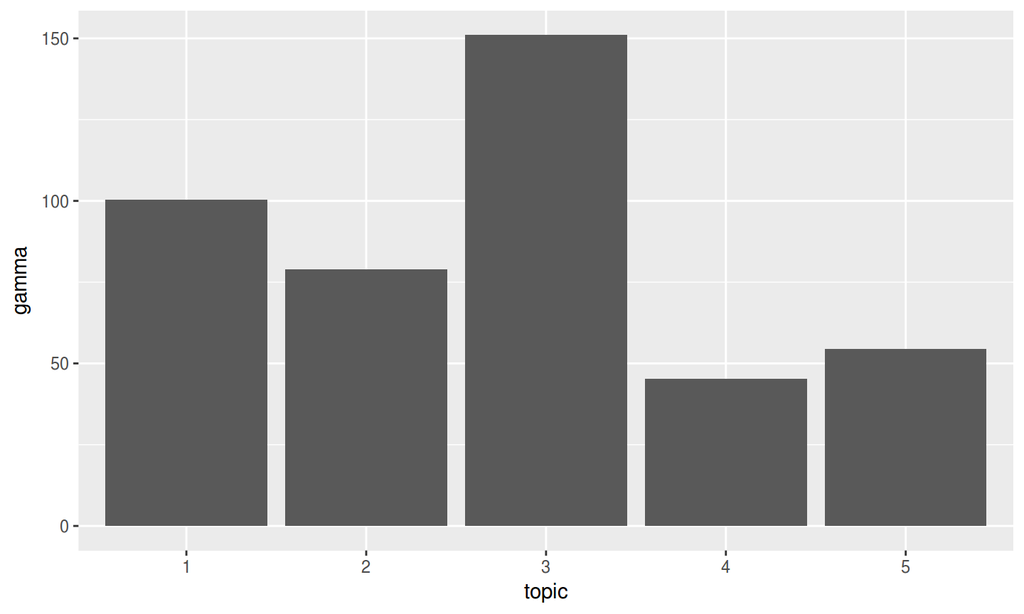

## Distribution of topics considering age of the author (I)

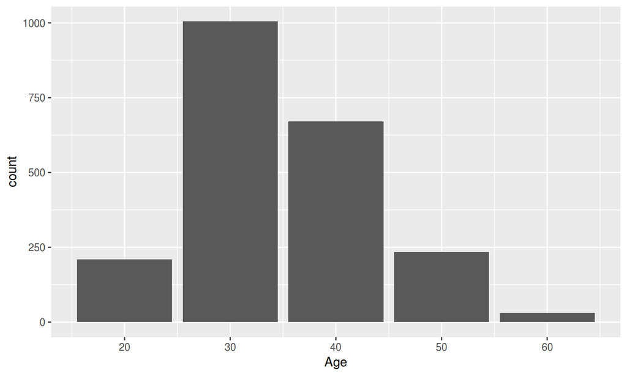

## Distribution of topics considering age of the author (II)

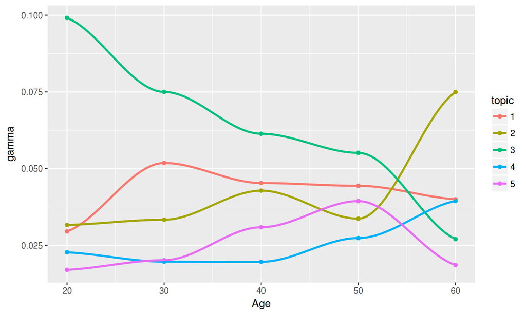

## Distribution of topics considering number of victims (I)

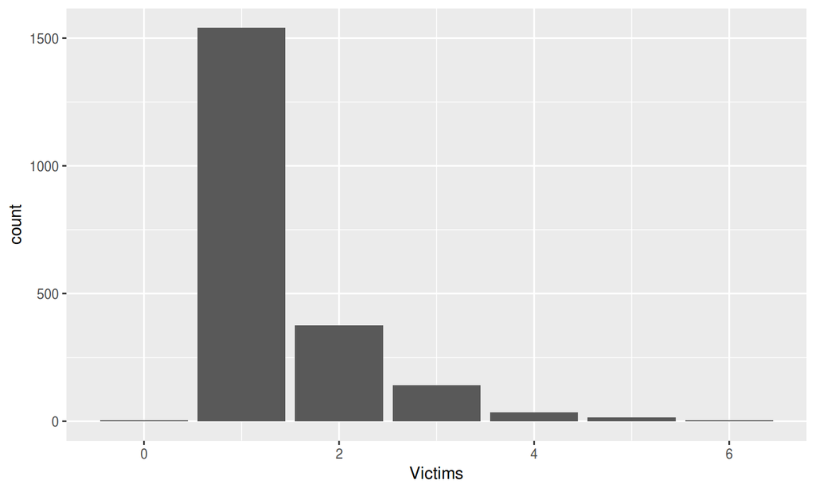

## Distribution of topics considering number of victims (II)

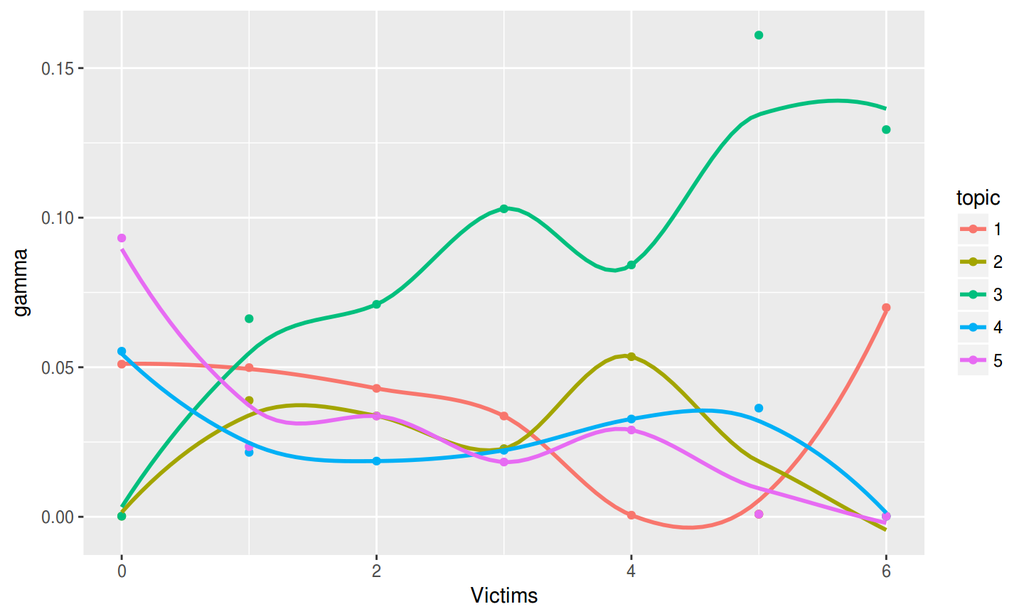

## Dataset 2016 U.S. Presidential Campaign Texts and Polls

It is a collection of transcripts that contains:

- the presidential debates of Trump and Clinton
- Trump's speeches delivered after the RNC and Clinton's speeches delivered after the DNC
- speeches delivered by Trump, Clinton and Sanders during the primary campaigns

## 2016 U.S. Presidential Campaign Texts

|  | text |
| --- | --- |
| 1 | How are you, Donald? Well, thank you, Lester, and thanks to Hofstra for hosting us. The central question in this election is really what kind of country we want to be and what kind of future we'll bui… |
| 2 | Well, thank you. Are you a teacher? Yes, I think that that's a very good question, because I've heard from lots of teachers and parents about some of their concerns about some of the things that are b… |
| 3 | Thank you very much, Chris. And thanks to UNLV for hosting us. You know, I think when we talk about the Supreme Court, it really raises the central issue in this election, namely, what kind of country… |
| 4 | Thank you, Lester. Our jobs are fleeing the country. They're going to Mexico. They're going to many other countries. You look at what China is doing to our country in terms of making our product. They… |
| 5 | Well, I actually agree with that. I agree with everything she said. I began this campaign because I was so tired of seeing such foolish things happen to our country. This is a great country. This is a… |
| 6 | Well, first of all, it's great to be with you, and thank you, everybody. The Supreme Court: It's what it's all about. Our country is so, so -- it's just so imperative that we have the right justices. … |

## Most used words in election documents

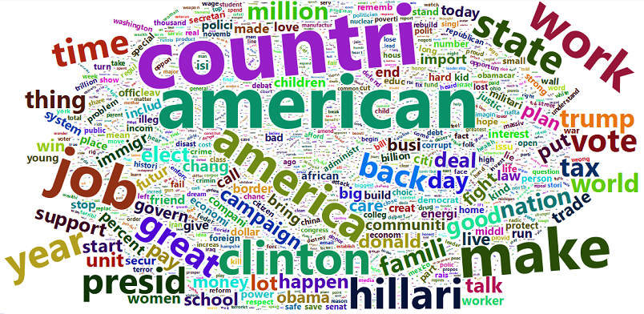

## LDA using VEM

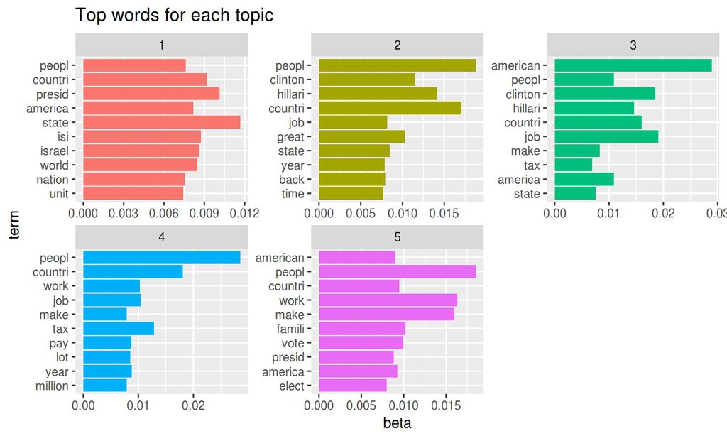

## Top relevant Words for each topic

\[relevance = \lambda*\log p(word|topic)+(1-\lambda)*\log\,\frac{p(word|topic)}{p(word)}\]

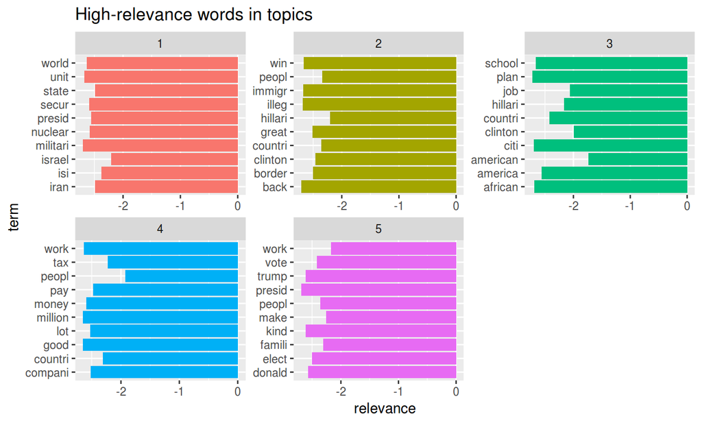

## Distribution of topics

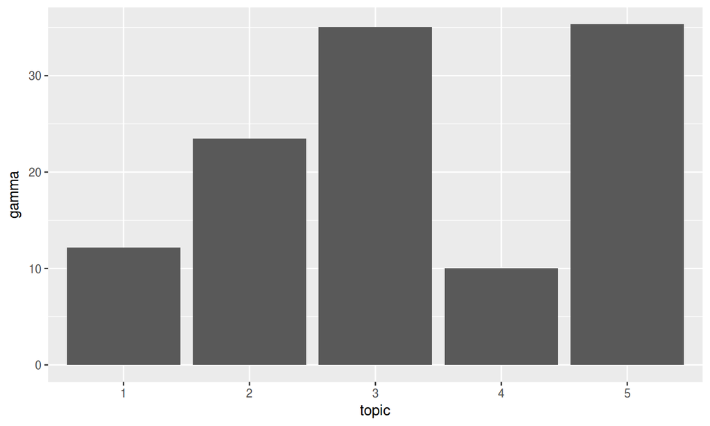

## Distribution of topics considering type of text (I)

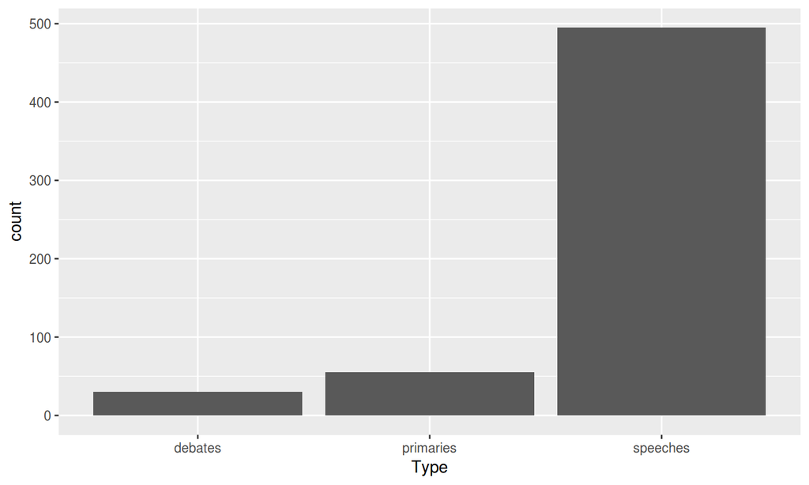

## Distribution of topics considering type of text (II)

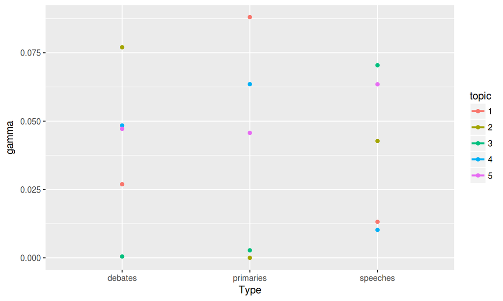

## Distribution of topics considering the author (I)

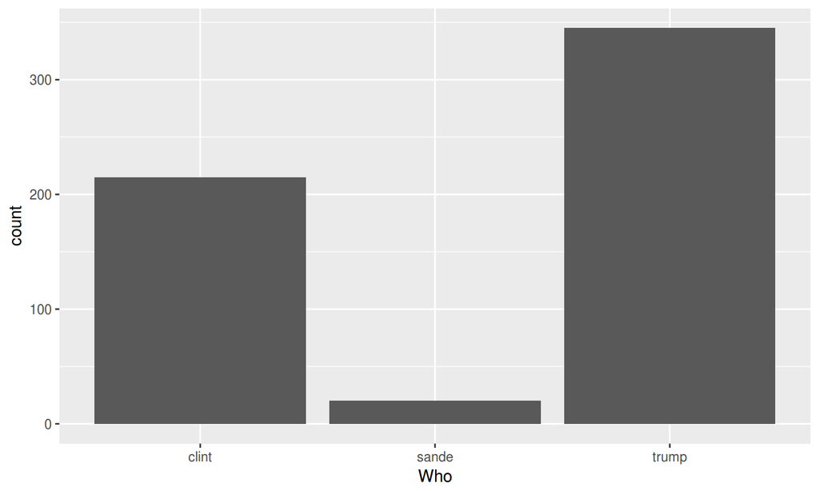

## Distribution of topics considering the author (II)

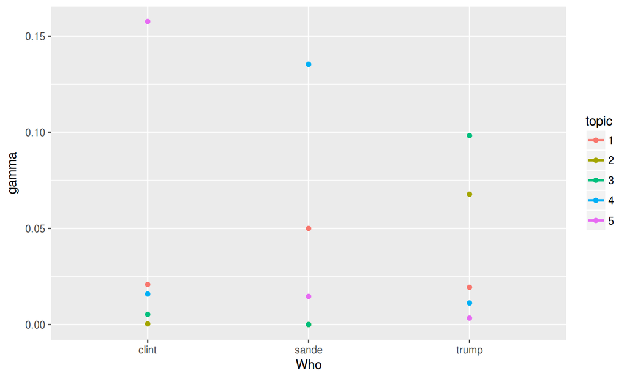

## Number of topics

To build the model you need to choose the number of topics.

Cross validation can be used to evaluate models based on different nummber of topics.

Two indexes are considered: perplexity and entropy.

## Number of topics cross validation results

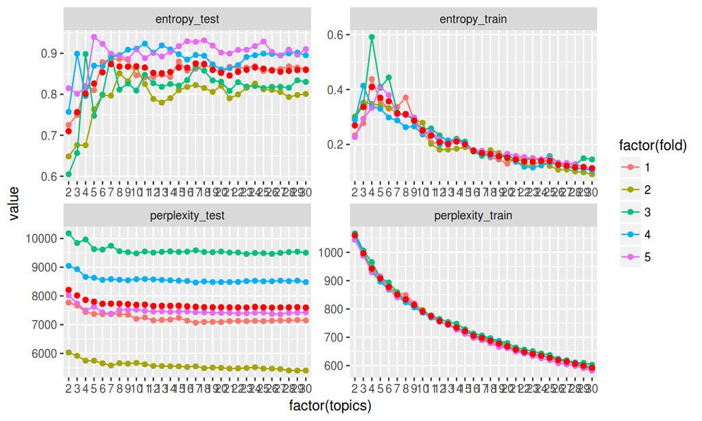

## Correlated Topic Models (I)

While LDA performs decently under opportune conditions, it fails to model the correlation between topics (or rather, it assumes a-priori uncorrelation between them).

One way to approach this problem is to modify our model to replace the Dirichlet distribution on the topics with a logistic normal distribution with mean \(\mu\) and correlation matrix \(\Sigma\), obtaining the following PGM schema:

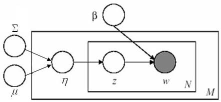

## Correlated Topic Models (II)

The resulting model can be estimated by VEM, but no analogous to the Gibbs sampling method currently exists for CTM.

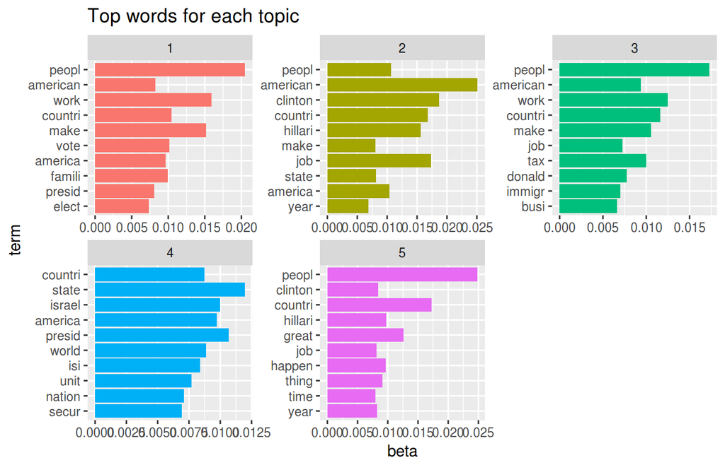

## Correlated Topic Models (III)

Due to the significant increase in the number of parameters in the prior distribution, the convergence of the algorithm is much slower. This performance tradeoff is often unfeasible (often 10x slower than regular LDA) and/or numerically unstable.

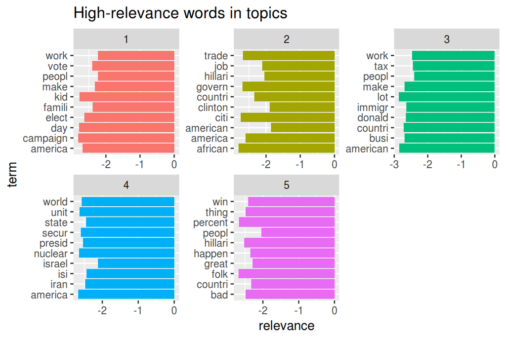

## Principal Component Analysis

Alternative ways to obtain from LDA a measure of affinity between different topics have been designed.

One such method, useful for data visualization, is based on PCA. Given each topic's distribution, we can compute the Jensen-Shannon divergence between each pair, obtaining a \(K\times K\) matrix; afterwards, we use classical multidimensional reduction on the obtained matrix to reduce the number of dimensions to 2 (typically). This way we associate to each topic a point in \(\mathbb{R}^2\).

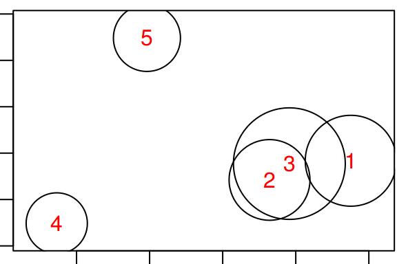